# HW1_HillT

```r
library(ggplot2)
library(dplyr)
library(readr)
library(reshape2)
library(purrr)
library(tidyr)
```

### Loading the initial data

```r
baseball_df <- read.csv('moneyball-training-data.csv')

head(baseball_df)
```

|  | INDEX | TARGET_WINS | TEAM_BATTING_H | TEAM_BATTING_2B | TEAM_BATTING_3B | TEAM_BATTING_HR | TEAM_BATTING_BB | TEAM_BATTING_SO | TEAM_BASERUN_SB | TEAM_BASERUN_CS | TEAM_BATTING_HBP | TEAM_PITCHING_H | TEAM_PITCHING_HR | TEAM_PITCHING_BB | TEAM_PITCHING_SO | TEAM_FIELDING_E | TEAM_FIELDING_DP |
| --- | --- | --- | --- | --- | --- | --- | --- | --- | --- | --- | --- | --- | --- | --- | --- | --- | --- |
| 1 | 1 | 39 | 1445 | 194 | 39 | 13 | 143 | 842 | NA | NA | NA | 9364 | 84 | 927 | 5456 | 1011 | NA |
| 2 | 2 | 70 | 1339 | 219 | 22 | 190 | 685 | 1075 | 37 | 28 | NA | 1347 | 191 | 689 | 1082 | 193 | 155 |
| 3 | 3 | 86 | 1377 | 232 | 35 | 137 | 602 | 917 | 46 | 27 | NA | 1377 | 137 | 602 | 917 | 175 | 153 |
| 4 | 4 | 70 | 1387 | 209 | 38 | 96 | 451 | 922 | 43 | 30 | NA | 1396 | 97 | 454 | 928 | 164 | 156 |
| 5 | 5 | 82 | 1297 | 186 | 27 | 102 | 472 | 920 | 49 | 39 | NA | 1297 | 102 | 472 | 920 | 138 | 168 |
| 6 | 6 | 75 | 1279 | 200 | 36 | 92 | 443 | 973 | 107 | 59 | NA | 1279 | 92 | 443 | 973 | 123 | 149 |

### Feature Boxplots and Histograms

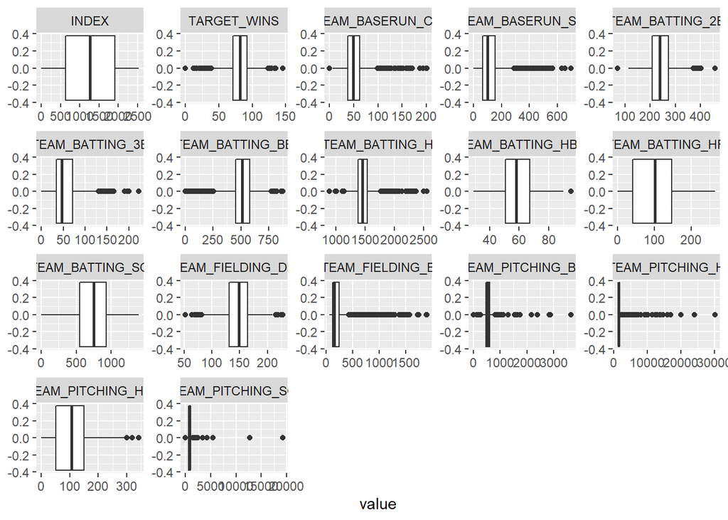

```r
baseball_df %>%
  keep(is.numeric) %>%
  gather() %>%
  ggplot(aes(value)) +
    facet_wrap(~ key, scales = "free") +
    geom_boxplot()
```

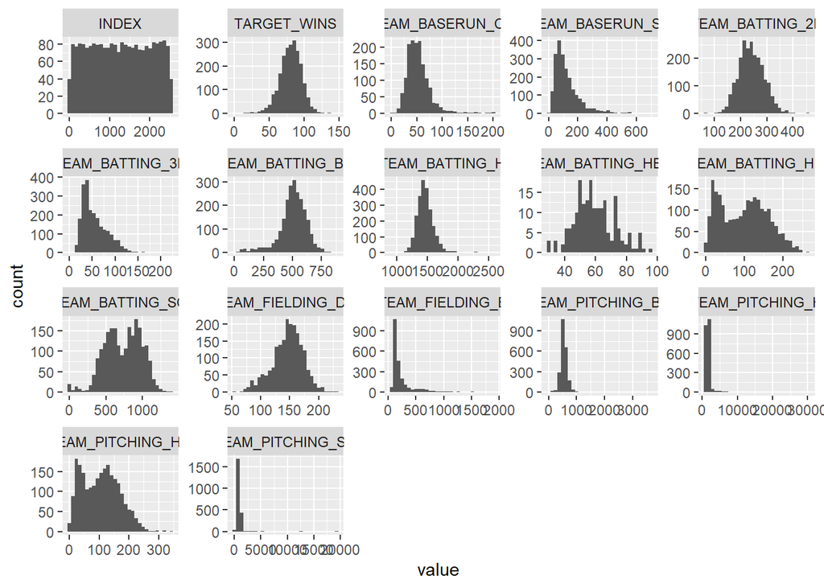

```r
baseball_df %>%
  keep(is.numeric) %>%
  gather() %>%
  ggplot(aes(value)) +
    facet_wrap(~ key, scales = "free") +
    geom_histogram()
```

### Summary Statistics

```r
summary(baseball_df)
```

```
##      INDEX         TARGET_WINS     TEAM_BATTING_H TEAM_BATTING_2B
##  Min.   :   1.0   Min.   :  0.00   Min.   : 891   Min.   : 69.0
##  1st Qu.: 630.8   1st Qu.: 71.00   1st Qu.:1383   1st Qu.:208.0
##  Median :1270.5   Median : 82.00   Median :1454   Median :238.0
##  Mean   :1268.5   Mean   : 80.79   Mean   :1469   Mean   :241.2
##  3rd Qu.:1915.5   3rd Qu.: 92.00   3rd Qu.:1537   3rd Qu.:273.0
##  Max.   :2535.0   Max.   :146.00   Max.   :2554   Max.   :458.0
##
##  TEAM_BATTING_3B  TEAM_BATTING_HR  TEAM_BATTING_BB TEAM_BATTING_SO
##  Min.   :  0.00   Min.   :  0.00   Min.   :  0.0   Min.   :   0.0
##  1st Qu.: 34.00   1st Qu.: 42.00   1st Qu.:451.0   1st Qu.: 548.0
##  Median : 47.00   Median :102.00   Median :512.0   Median : 750.0
##  Mean   : 55.25   Mean   : 99.61   Mean   :501.6   Mean   : 735.6
##  3rd Qu.: 72.00   3rd Qu.:147.00   3rd Qu.:580.0   3rd Qu.: 930.0
##  Max.   :223.00   Max.   :264.00   Max.   :878.0   Max.   :1399.0
##                                                    NA's   :102
##  TEAM_BASERUN_SB TEAM_BASERUN_CS TEAM_BATTING_HBP TEAM_PITCHING_H
##  Min.   :  0.0   Min.   :  0.0   Min.   :29.00    Min.   : 1137
##  1st Qu.: 66.0   1st Qu.: 38.0   1st Qu.:50.50    1st Qu.: 1419
##  Median :101.0   Median : 49.0   Median :58.00    Median : 1518
##  Mean   :124.8   Mean   : 52.8   Mean   :59.36    Mean   : 1779
##  3rd Qu.:156.0   3rd Qu.: 62.0   3rd Qu.:67.00    3rd Qu.: 1682
##  Max.   :697.0   Max.   :201.0   Max.   :95.00    Max.   :30132
##  NA's   :131     NA's   :772     NA's   :2085
##  TEAM_PITCHING_HR TEAM_PITCHING_BB TEAM_PITCHING_SO  TEAM_FIELDING_E
##  Min.   :  0.0    Min.   :   0.0   Min.   :    0.0   Min.   :  65.0
##  1st Qu.: 50.0    1st Qu.: 476.0   1st Qu.:  615.0   1st Qu.: 127.0
##  Median :107.0    Median : 536.5   Median :  813.5   Median : 159.0
##  Mean   :105.7    Mean   : 553.0   Mean   :  817.7   Mean   : 246.5
##  3rd Qu.:150.0    3rd Qu.: 611.0   3rd Qu.:  968.0   3rd Qu.: 249.2
##  Max.   :343.0    Max.   :3645.0   Max.   :19278.0   Max.   :1898.0
##                                    NA's   :102
##  TEAM_FIELDING_DP
##  Min.   : 52.0
##  1st Qu.:131.0
##  Median :149.0
##  Mean   :146.4
##  3rd Qu.:164.0
##  Max.   :228.0
##  NA's   :286
```

```r
colSums(is.na(baseball_df))
```

```
##            INDEX      TARGET_WINS   TEAM_BATTING_H  TEAM_BATTING_2B
##                0                0                0                0
##  TEAM_BATTING_3B  TEAM_BATTING_HR  TEAM_BATTING_BB  TEAM_BATTING_SO
##                0                0                0              102
##  TEAM_BASERUN_SB  TEAM_BASERUN_CS TEAM_BATTING_HBP  TEAM_PITCHING_H
##              131              772             2085                0
## TEAM_PITCHING_HR TEAM_PITCHING_BB TEAM_PITCHING_SO  TEAM_FIELDING_E
##                0                0              102                0
## TEAM_FIELDING_DP
##              286
```

### Fitting a Linear Model

My first change to the data was to eliminate the index and two problem variables with many misisng variables: when batters are hit by pitch or caught stealing.

```r
baseball_df_fix <- subset(baseball_df, select = -c(TEAM_BATTING_HBP,TEAM_BASERUN_CS, INDEX))

baseball_lm <- lm(baseball_df_fix, formula = TARGET_WINS ~  TEAM_PITCHING_H + TEAM_PITCHING_HR + TEAM_FIELDING_DP + TEAM_BATTING_3B + TEAM_BATTING_H:TEAM_BATTING_HR + TEAM_BATTING_2B:TEAM_BATTING_HR+ log(TEAM_FIELDING_E) + log(TEAM_PITCHING_BB) + log(TEAM_PITCHING_SO) + log(TEAM_BASERUN_SB))

summary(baseball_lm)
```

```
##
## Call:
## lm(formula = TARGET_WINS ~ TEAM_PITCHING_H + TEAM_PITCHING_HR +
##     TEAM_FIELDING_DP + TEAM_BATTING_3B + TEAM_BATTING_H:TEAM_BATTING_HR +
##     TEAM_BATTING_2B:TEAM_BATTING_HR + log(TEAM_FIELDING_E) +
##     log(TEAM_PITCHING_BB) + log(TEAM_PITCHING_SO) + log(TEAM_BASERUN_SB),
##     data = baseball_df_fix)
##
## Residuals:
##     Min      1Q  Median      3Q     Max
## -32.251  -7.220   0.246   7.366  30.338
##
## Coefficients:
##                                   Estimate Std. Error t value Pr(>|t|)
## (Intercept)                      1.273e+02  1.784e+01   7.137 1.37e-12 ***
## TEAM_PITCHING_H                  6.416e-03  1.998e-03   3.211  0.00135 **
## TEAM_PITCHING_HR                -1.139e-01  2.792e-02  -4.080 4.71e-05 ***
## TEAM_FIELDING_DP                -1.186e-01  1.229e-02  -9.649  < 2e-16 ***
## TEAM_BATTING_3B                  1.998e-01  1.905e-02  10.490  < 2e-16 ***
## log(TEAM_FIELDING_E)            -2.043e+01  1.291e+00 -15.823  < 2e-16 ***
## log(TEAM_PITCHING_BB)            1.849e+01  1.639e+00  11.279  < 2e-16 ***
## log(TEAM_PITCHING_SO)           -1.413e+01  1.714e+00  -8.244 3.14e-16 ***
## log(TEAM_BASERUN_SB)             5.064e+00  5.363e-01   9.442  < 2e-16 ***
## TEAM_BATTING_H:TEAM_BATTING_HR   2.337e-04  2.351e-05   9.942  < 2e-16 ***
## TEAM_BATTING_HR:TEAM_BATTING_2B -5.488e-04  6.655e-05  -8.247 3.07e-16 ***
## ---
## Signif. codes:  0 '***' 0.001 '**' 0.01 '*' 0.05 '.' 0.1 ' ' 1
##
## Residual standard error: 10.34 on 1824 degrees of freedom
##   (441 observations deleted due to missingness)
## Multiple R-squared:  0.3864, Adjusted R-squared:  0.383
## F-statistic: 114.9 on 10 and 1824 DF,  p-value: < 2.2e-16
```

```r
baseball_interactions <- lm(baseball_df_fix, formula = TARGET_WINS ~ (TEAM_BATTING_H * TEAM_BATTING_2B + TEAM_BATTING_H * TEAM_BATTING_3B + TEAM_BATTING_H * TEAM_BATTING_HR))

summary(baseball_interactions)
```

```
##
## Call:
## lm(formula = TARGET_WINS ~ (TEAM_BATTING_H * TEAM_BATTING_2B +
##     TEAM_BATTING_H * TEAM_BATTING_3B + TEAM_BATTING_H * TEAM_BATTING_HR),
##     data = baseball_df_fix)
##
## Residuals:
##     Min      1Q  Median      3Q     Max
## -68.807  -8.816   0.569   9.585  58.270
##
## Coefficients:
##                                  Estimate Std. Error t value Pr(>|t|)
## (Intercept)                    -7.961e+00  1.291e+01  -0.616 0.537654
## TEAM_BATTING_H                  4.868e-02  9.039e-03   5.386 7.97e-08 ***
## TEAM_BATTING_2B                -2.802e-02  5.708e-02  -0.491 0.623581
## TEAM_BATTING_3B                 4.678e-01  1.016e-01   4.605 4.34e-06 ***
## TEAM_BATTING_HR                 2.462e-01  6.928e-02   3.553 0.000388 ***
## TEAM_BATTING_H:TEAM_BATTING_2B  2.323e-05  3.814e-05   0.609 0.542590
## TEAM_BATTING_H:TEAM_BATTING_3B -2.231e-04  6.497e-05  -3.434 0.000606 ***
## TEAM_BATTING_H:TEAM_BATTING_HR -1.108e-04  4.622e-05  -2.397 0.016596 *
## ---
## Signif. codes:  0 '***' 0.001 '**' 0.01 '*' 0.05 '.' 0.1 ' ' 1
##
## Residual standard error: 14.05 on 2268 degrees of freedom
## Multiple R-squared:  0.2074, Adjusted R-squared:  0.2049
## F-statistic: 84.77 on 7 and 2268 DF,  p-value: < 2.2e-16
```

In the histograms above, I noticed some of the data was bimodal in some cases. I approximated some dummy variables to see if they added to the linear model. This part ended up being a dead end and I’ll instead use the Box-Cox method to transform these variables later in the week.

```r
baseball_dummies <- baseball_df_fix %>%
  mutate(TEAM_PITCHING_HR_70 = case_when(TEAM_PITCHING_HR <= 70 ~ 1, TEAM_PITCHING_HR > 70 ~ 0)) %>%
  mutate(TEAM_BATTING_SO_750 = case_when(TEAM_BATTING_SO  > 750 ~ 1, (TEAM_BATTING_SO  <= 750 | is.na(TEAM_BATTING_SO)) ~ 0)) %>%
  mutate(TEAM_BATTING_HR_60 = case_when(TEAM_BATTING_HR  > 60 ~ 1, TEAM_BATTING_HR  <= 60 ~ 0))
```

### Final Model using all Training Ddata

For my final model I considered, I originally modeled all of the dummy variables but they ended up not contributing anything to the model. This final model eliminates several features altogether, transforms three, and considers four different interaction effects.

```r
baseball_lm2 <- lm(baseball_df_fix, formula = TARGET_WINS ~. +log(TEAM_FIELDING_E) +log(TEAM_PITCHING_SO) + log(TEAM_BASERUN_SB) + TEAM_BATTING_3B:TEAM_BATTING_HR + TEAM_BATTING_2B:TEAM_BATTING_HR +  TEAM_BATTING_H:TEAM_BATTING_HR + TEAM_BATTING_H:TEAM_BATTING_3B- TEAM_BATTING_3B - TEAM_BATTING_SO - TEAM_BATTING_2B-TEAM_BATTING_BB-TEAM_BATTING_HR-TEAM_BATTING_H-TEAM_BATTING_HR- TEAM_PITCHING_HR)


summary(baseball_lm2)
```

```
##
## Call:
## lm(formula = TARGET_WINS ~ . + log(TEAM_FIELDING_E) + log(TEAM_PITCHING_SO) +
##     log(TEAM_BASERUN_SB) + TEAM_BATTING_3B:TEAM_BATTING_HR +
##     TEAM_BATTING_2B:TEAM_BATTING_HR + TEAM_BATTING_H:TEAM_BATTING_HR +
##     TEAM_BATTING_H:TEAM_BATTING_3B - TEAM_BATTING_3B - TEAM_BATTING_SO -
##     TEAM_BATTING_2B - TEAM_BATTING_BB - TEAM_BATTING_HR - TEAM_BATTING_H -
##     TEAM_BATTING_HR - TEAM_PITCHING_HR, data = baseball_df_fix)
##
## Residuals:
##     Min      1Q  Median      3Q     Max
## -32.369  -6.994   0.202   6.859  29.847
##
## Coefficients:
##                                   Estimate Std. Error t value Pr(>|t|)
## (Intercept)                      8.746e-01  4.314e+01   0.020 0.983829
## TEAM_BASERUN_SB                  9.452e-02  1.557e-02   6.072 1.54e-09 ***
## TEAM_PITCHING_H                  4.775e-03  2.058e-03   2.320 0.020446 *
## TEAM_PITCHING_BB                 3.036e-02  2.836e-03  10.705  < 2e-16 ***
## TEAM_PITCHING_SO                -5.275e-02  7.697e-03  -6.854 9.80e-12 ***
## TEAM_FIELDING_E                 -5.201e-02  2.103e-02  -2.473 0.013474 *
## TEAM_FIELDING_DP                -1.119e-01  1.220e-02  -9.179  < 2e-16 ***
## log(TEAM_FIELDING_E)            -1.290e+01  3.897e+00  -3.312 0.000945 ***
## log(TEAM_PITCHING_SO)            2.552e+01  6.367e+00   4.008 6.38e-05 ***
## log(TEAM_BASERUN_SB)            -3.154e+00  1.457e+00  -2.165 0.030491 *
## TEAM_BATTING_3B:TEAM_BATTING_HR -8.208e-04  2.619e-04  -3.134 0.001752 **
## TEAM_BATTING_2B:TEAM_BATTING_HR -3.967e-04  6.568e-05  -6.040 1.86e-09 ***
## TEAM_BATTING_H:TEAM_BATTING_HR   1.553e-04  1.565e-05   9.924  < 2e-16 ***
## TEAM_BATTING_H:TEAM_BATTING_3B   1.823e-04  1.875e-05   9.722  < 2e-16 ***
## ---
## Signif. codes:  0 '***' 0.001 '**' 0.01 '*' 0.05 '.' 0.1 ' ' 1
##
## Residual standard error: 10.11 on 1821 degrees of freedom
##   (441 observations deleted due to missingness)
## Multiple R-squared:  0.4144, Adjusted R-squared:  0.4102
## F-statistic: 99.11 on 13 and 1821 DF,  p-value: < 2.2e-16
```

The R-squared statistic indicates that this model predicts less than half of the variation in wins with the included features. For a next step, I hope to use cross-validation techniques to split the training data further and allow me to compare RMSE of various models.

### Evaluation Data

I also loaded the evaluation data and predicted the wins using my final model. Since the actual wins are withheld, I compared the distribution of predictions to the actual wins in the training set. The means were similar but the training data included much more variation between teams. It’s also worth mentioning as well that using the predict function creates missing values as the evaluation data is missing. In fact, for TEAM_BATTING_HBP, over 90% of rows are missing entries.

```r
baseball_eval <- read.csv('moneyball-evaluation-data.csv')

colSums(is.na(baseball_eval))
```

```
##            INDEX   TEAM_BATTING_H  TEAM_BATTING_2B  TEAM_BATTING_3B
##                0                0                0                0
##  TEAM_BATTING_HR  TEAM_BATTING_BB  TEAM_BATTING_SO  TEAM_BASERUN_SB
##                0                0               18               13
##  TEAM_BASERUN_CS TEAM_BATTING_HBP  TEAM_PITCHING_H TEAM_PITCHING_HR
##               87              240                0                0
## TEAM_PITCHING_BB TEAM_PITCHING_SO  TEAM_FIELDING_E TEAM_FIELDING_DP
##                0               18                0               31
```

```r
baseball_vars <- baseball_eval %>%
  select(TEAM_PITCHING_H, TEAM_PITCHING_HR, TEAM_FIELDING_DP, TEAM_BATTING_3B, TEAM_FIELDING_E, TEAM_PITCHING_BB, TEAM_PITCHING_SO, TEAM_BASERUN_SB, TEAM_BATTING_H, TEAM_BATTING_HR, TEAM_BATTING_2B)

eval_predict <- predict(baseball_interactions, newdata = baseball_eval)
```

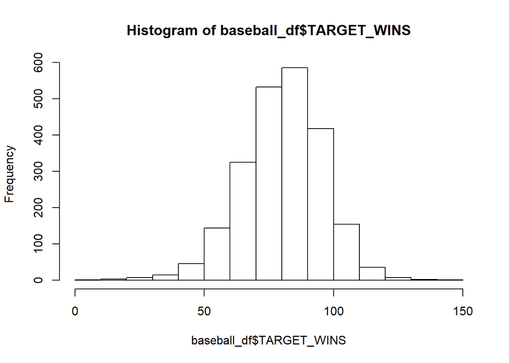

```r
hist(baseball_df$TARGET_WINS)
```

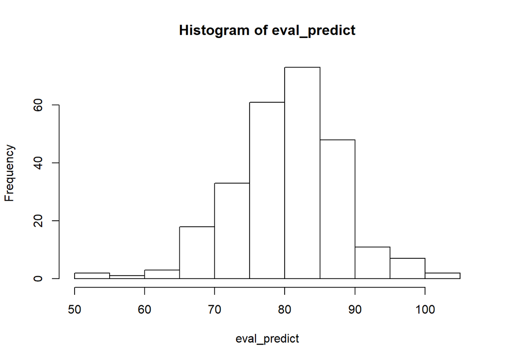

```r
hist(eval_predict)
```

```r
summary(eval_predict)
```

```
##    Min. 1st Qu.  Median    Mean 3rd Qu.    Max.
##   54.33   75.52   80.85   80.47   85.46  102.01
```

```r
sd(eval_predict)
```

```
## [1] 7.711588
```

```r
summary(baseball_df$TARGET_WINS)
```

```
##    Min. 1st Qu.  Median    Mean 3rd Qu.    Max.
##    0.00   71.00   82.00   80.79   92.00  146.00
```

```r
sd(baseball_df$TARGET_WINS)
```

```
## [1] 15.75215
```

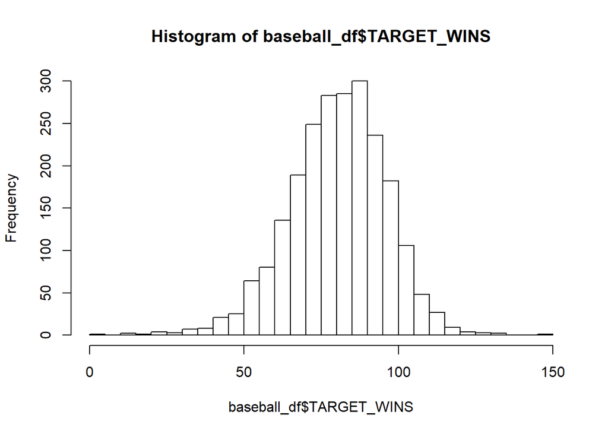

```r
eval_predict2 <- predict(baseball_lm2, newdata = baseball_eval)

hist(baseball_df$TARGET_WINS, breaks = 40)
```

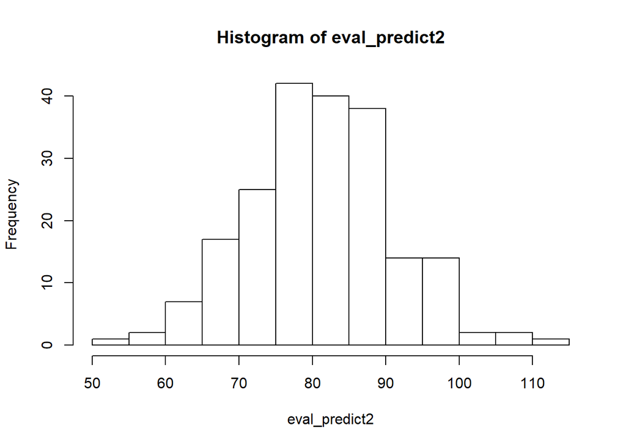

```r
hist(eval_predict2)
```

```r
summary(eval_predict2)
```

```
##    Min. 1st Qu.  Median    Mean 3rd Qu.    Max.    NA's
##   53.70   74.52   80.91   81.02   87.53  114.55      54
```

```r
sd(eval_predict2, na.rm = T)
```

```
## [1] 9.932411
```

```r
n_test <-nrow(baseball_eval)
n_train <- nrow(baseball_df)

summary(baseball_df$TARGET_WINS)
```

```
##    Min. 1st Qu.  Median    Mean 3rd Qu.    Max.
##    0.00   71.00   82.00   80.79   92.00  146.00
```

```r
sd(baseball_df$TARGET_WINS)
```

```
## [1] 15.75215
```